# R Notebook

```r
summary(mortgage_data_logreg_model)
```

```
Call:
glm(formula = accepted ~ tu_score, family = binomial(link = "logit"),
    data = mortgage_data)

Deviance Residuals:
    Min       1Q   Median       3Q      Max
-1.8077  -0.6087  -0.2703   0.6851   3.0227

Coefficients:
             Estimate Std. Error z value Pr(>|z|)
(Intercept) -4.575035   0.285035  -16.05   <2e-16 ***
tu_score     0.008475   0.000566   14.97   <2e-16 ***
---
Signif. codes:  0 ‘***’ 0.001 ‘**’ 0.01 ‘*’ 0.05 ‘.’ 0.1 ‘ ’ 1

(Dispersion parameter for binomial family taken to be 1)

    Null deviance: 1170.48  on 999  degrees of freedom
Residual deviance:  792.14  on 998  degrees of freedom
AIC: 796.14

Number of Fisher Scoring iterations: 5
```

probability of acceptance = 1/ 1 + e^(-4.6+0.01*tu_score)

as tu_score increases by 1, probability increases the log odds by 0.008

| tu_score | pred |
| --- | --- |
| 600 | 0.6247912 |

how do our odds of getting accpeted change as we increase tu_score?

base on: - baseline odds (tu_score = 594) - odds above baseline (tu_score = 594 + 50)

```r
odds_change <- function(b1, change){
  exp(b1 * change)
}

odds_change(0.008475, 50)
```

```
[1] 1.52768
```

a 50 unit increase in tu_score leads to odds increasing by a factor of 1.53

###categorical predictors

```r
mortgage_model_2_terms
```

```
Call:  glm(formula = accepted ~ tu_score + employed, family = binomial(link = "logit"),
    data = mortgage_data)

Coefficients:
 (Intercept)      tu_score  employedTRUE
   -4.686827      0.006724      1.484538

Degrees of Freedom: 999 Total (i.e. Null);  997 Residual
Null Deviance:      1170
Residual Deviance: 740  AIC: 746
```

ln(oddsaccepted) = b0 = b1 * 0.006724 + 1.484538 * employedTrue

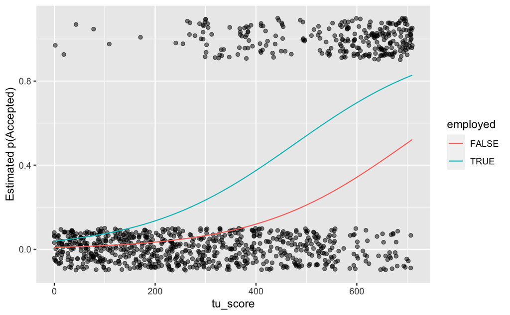

```r
log_predictions <- tibble(
  tu_score = rep(seq(0, 710, 1), 2),
  employed = c(rep(TRUE, 711), rep(FALSE, 711))
) %>%
  add_predictions(model = mortgage_model_2_terms, type = "response")

ggplot(mortgage_data) +
  geom_jitter(aes(x = tu_score, y = as.numeric(accepted)), alpha = 0.5, height = 0.1, width = 0.1) +
  geom_line(data = log_predictions, aes(x = tu_score, y = pred, colour = employed)) +
  labs(y = "Estimated p(Accepted)")
```

```r
# can use our predictions by filtering our prediction table
log_predictions %>%
  filter(tu_score == 600)
```

| tu_score | employed | pred |
| --- | --- | --- |
| 600 | TRUE | 0.6967935 |
| 600 | FALSE | 0.3424347 |

odds(employedTrue) / odds(employedFalse) = odds ratio

```r
odds_change(1.48, 1)
```

```
[1] 4.392946
```

on average a customers odds of being accepted are 4.39x higher if they’re employed

###model performance: building a binary classifier

i.e. assigns a class based on this predicted probability

if applicant’s credit score is x and their employment is y, will we accpet them for a mortgage loan?

the probability level which we assign yes or no is called the threshold

| tu_score | employed | age | accepted | pred | predicted_accepted |
| --- | --- | --- | --- | --- | --- |
| 433 | TRUE | 28 | TRUE | 0.427802324 | FALSE |
| 93 | TRUE | 52 | FALSE | 0.070635832 | FALSE |
| 368 | FALSE | 63 | FALSE | 0.098640937 | FALSE |
| 665 | TRUE | 42 | TRUE | 0.780593943 | TRUE |
| 687 | TRUE | 38 | TRUE | 0.804876732 | TRUE |
| 594 | TRUE | 27 | FALSE | 0.688202922 | TRUE |
| 83 | FALSE | 24 | FALSE | 0.015847947 | FALSE |
| 172 | TRUE | 19 | FALSE | 0.114480316 | FALSE |
| 27 | FALSE | 45 | FALSE | 0.010929705 | FALSE |
| 232 | FALSE | 34 | FALSE | 0.042012269 | FALSE |

[output cut: 990 more lines]

###model assessment - how often were we right (accepted = predicted_accepted)

confusion tool assessment matrix

```r
library(janitor)
mortgage_preds_2_terms %>%
  tabyl(accepted, predicted_accepted)
```

```
 accepted FALSE TRUE
    FALSE   678   50
     TRUE    93  179
```

> task

```r
conf_mat
```

```
          predicted_accepted
 accepted              FALSE TRUE
    FALSE                701   27
     TRUE                102  170
```

FALSE:FALSE & TRUE:TRUE are where your model is right

FALSE:TRUE & TRUE:FALSE are where your model is wrong

> task

```r
mortgage_data %>%
  filter(tu_score == 594)
```

| tu_score | employed | age | accepted |
| --- | --- | --- | --- |
| 594 | TRUE | 27 | FALSE |
| 594 | TRUE | 47 | FALSE |
| 594 | TRUE | 33 | TRUE |
| 594 | TRUE | 36 | TRUE |
| 594 | TRUE | 45 | TRUE |

```r
mortgage_data_with_3_pred %>%
  filter(tu_score == 594)
```

| tu_score | employed | age | accepted | pred | predicted_accepted |
| --- | --- | --- | --- | --- | --- |
| 594 | TRUE | 27 | FALSE | 0.8154718 | TRUE |
| 594 | TRUE | 47 | FALSE | 0.7902718 | TRUE |
| 594 | TRUE | 33 | TRUE | 0.8079118 | TRUE |
| 594 | TRUE | 36 | TRUE | 0.8041318 | TRUE |
| 594 | TRUE | 45 | TRUE | 0.7927918 | TRUE |

#single value for accuracy?

Accuracy: number of true pos. + number of true neg. / total - times we were right / total outcomes

```r
(701+170) / 1000
```

```
[1] 0.871
```

we were right 87.1% of the time

unfortunately accuracy doesn’t react well to unbalanced data: so we use other measures: - rates (true positive rate, specificity, …) - AUC - Gini

```r
false_negative_rate
```

```
[1] 0.375
```

which to prioritise depends on the context